# NFL Quarterback passing

Andrew Mellor

06/05/2020

## Overview

The purpose of this document is to answer these questions:

**How does passer rating relate to success? We can use the number of wins (wins) a team has when a particular quarterback starts as a measure of success. And then the questions we are trying to answer now are: Do quarterbacks with a higher passer rating have more wins? Do quarterbacks with a lower passer rating have fewer wins? How many wins can we expect to get when we have a starting quarterback with a particular passer rating?**

We can use simple linear regression to answer these questions.

## Load required packages

```r
#Include all required packages at the start
library(tidyverse)
library(ggplot2)
library(broom)
```

## Data

The data we will be using for this activity can be found in the 2019_nfl_qb_data.csv file and contains Quarterback stats for all quarterbacks in the 2019 NFL season. It has been sourced from [pro-football-reference.com](https://www.pro-football-reference.com/years/2019/passing) and consists of the following variables:

The [data](https://unicanberra.instructure.com/courses/7493/files/1778304) was provided by Dr Jocelyn Mara from the University of Canberra[^1].

**It is probably important to note some of the data points that are not self explanatory:**

1. case_no: unique observation identification number
2. player_name: quarterback player name
3. player_id: unique player identification number
4. team: team the quarterback plays for in the NFL
5. age: age of player in years
6. position: Uppercase QB indicates a primary starting quarterback, while lowercase qb
7. indicates a secondary quarterback
8. games_played: number of games played
9. games_started: number of games started
10. wins: number of games won when starting
11. losses: number of games lost when starting
12. draws: number of games drawn when starting
13. completions: number of passes completed
14. attempts: number of passes attempted
15. cmp_pc: passes completed as a percentage of passes attempted
16. yards: yards gained by passing
17. touchdowns: number of passing touchdowns
18. touchdown_pc: passing touchdowns as a percentage of passes attempted
19. interceptions: number of interceptions
20. interceptions_pc: interceptions as a percentage of passes attempted
21. passer_rating: Passer rating (also known as quarterback rating). For a description of the Passer rating see [here](https://en.wikipedia.org/wiki/Passer_rating)
22. sacks: number of [sacks](https://en.wikipedia.org/wiki/Quarterback_sack)
23. yards_lost: number of yards lost due to sacks
24. sack_pc: sacks as a percentage of passes attempted
25. Each row is one players total stats for the 2019 season.

## Read in Data

Read in the `2019_nfl_qb_data.csv` file using the `read_csv()` function from the `readr` package.

```r
#Read in the data
#data dir should be in the working directory
df <- read_csv("data/2019_nfl_qb_data.csv")
```

## Checking the data

```r
str(df) #provides structure of df


head(df) #shows first 6 rows of df


tail(df) #shows last 6 rows of df
```

[output not shown]

```r
#Check for missing values
sum(is.na(df))
```

[output not shown]

## Data Transformation

For this step, do the following in one sequence of code:

1. filter the data so only quarterbacks that have started a minimum of 10 games are included,
2. create a new variable called win_percentage, that expresses the number of wins as a percentage of games_started Save the result in a new object.

```r
#Create win_percentage
df2 <- df %>%
filter(games_started >= 10) %>%
mutate(win_percentage = wins / games_started * 100)

view(df2)
```

## Exploratory analysis

### Relationship between passer_rating and win_percentage

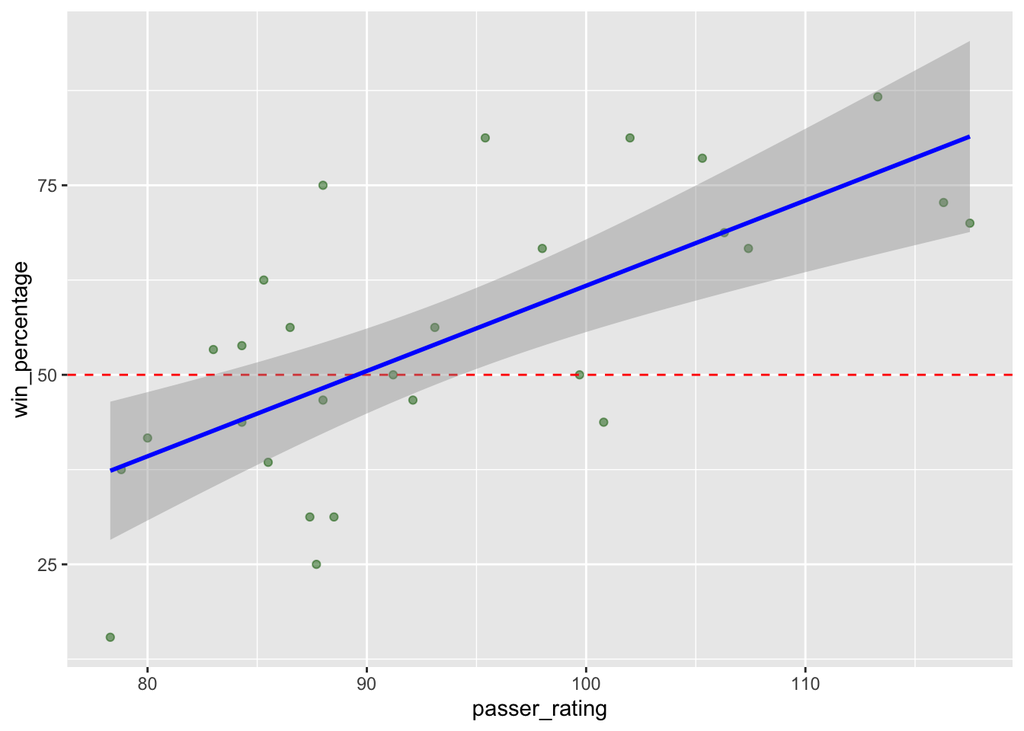

Here we can see our initial results showing some sort of relationship, **it is positive (that is as the x value increases so does the y value)**, x = passer_rating and y= win_percentage for our Quarterbacks.

```r
#Check if there is a correlation
cor (x = df2$passer_rating, y = df2$win_percentage, method = "pearson")
```

```
## [1] 0.6863687
```

As suggested the correlation is positive, but it is not strong as it is not that close to 1.

## Simple Linear Regression

```r
#Check the data relating a a simple linear regression
fit <- lm(win_percentage ~ passer_rating, data = df2)

summary(fit)
```

```
##
## Call:
## lm(formula = win_percentage ~ passer_rating, data = df2)
##
## Residuals:
##      Min       1Q   Median       3Q      Max
## -22.9162  -8.3727  -0.3736   9.8045  26.7463
##
## Coefficients:
##               Estimate Std. Error t value Pr(>|t|)
## (Intercept)   -50.7307    22.0564  -2.300   0.0297 *
## passer_rating   1.1248     0.2337   4.812 5.51e-05 ***
## ---
## Signif. codes:  0 '***' 0.001 '**' 0.01 '*' 0.05 '.' 0.1 ' ' 1
##
## Residual standard error: 13.68 on 26 degrees of freedom
## Multiple R-squared:  0.4711, Adjusted R-squared:  0.4508
## F-statistic: 23.16 on 1 and 26 DF,  p-value: 5.515e-05
```

```r
tidy(fit, conf.int = TRUE)
```

```
## # A tibble: 2 x 7
##   term          estimate std.error statistic   p.value conf.low conf.high
##   <chr>            <dbl>     <dbl>     <dbl>     <dbl>    <dbl>     <dbl>
## 1 (Intercept)     -50.7     22.1       -2.30 0.0297     -96.1       -5.39
## 2 passer_rating     1.12     0.234      4.81 0.0000551    0.644      1.61
```

The intercept, which is a measure of Y, when X = 0. The data tells us that **a Quarterback with a passer_rating of 0, should on average have a win_percentage of -50.730711. This is not possible as a Quarterback cannot have a win_percentage of less than 0.**

If we look at the confidence intervals, the best case scenario for a Quarterback with a passer_rating of 0 is still -5.393196, worst case scenario is -96.068227

The slope, is a measure of how much Y changes if we increase X by 1. In this case **if we can increase our passer_rating by 1, then we will increase our win_percentage by 1.124823.**

We can look at the confidence intervals using our equation for predicted values: Y = Intercept + (passer_rating * Slope) y = b + mx

Quarterback with a passer_rating of 100

```r
100*1.605274 + -5.393196 #highest win %
```

```
## [1] 155.1342
```

```r
100*0.644371 + -96.068227 #lowest win %
```

```
## [1] -31.63113
```

```r
100*1.124823 + -50.73711 #probable win %
```

```
## [1] 61.74519
```

## Independence of Observations

```r
#Determine if the observations are independent
car::durbinWatsonTest(fit)
```

```
##  lag Autocorrelation D-W Statistic p-value
##    1      -0.2092827      2.372391   0.318
##  Alternative hypothesis: rho != 0
```

The Durbin-Watson statistic shows: a value of approximately 2 (2.37), indicating that there is no correlation between the residuals and that we have independence of observations.

## Outliers

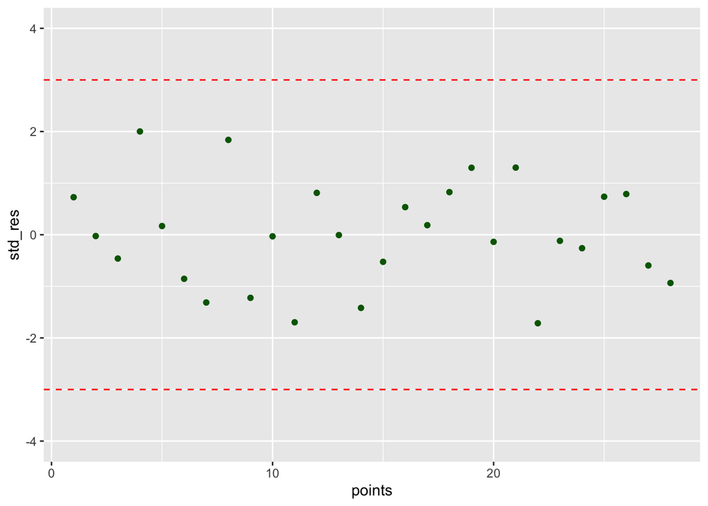

```r
#Check the data for outliers
std_res <- rstandard(fit)
points <- 1:length(std_res)

ggplot(data = NULL, aes(x = points, y = std_res)) +
geom_point(colour = "darkgreen") +
ylim(c(-4, 4)) +
geom_hline(yintercept = c(-3, 3), colour = "red", linetype = "dashed")
```

There do not appear to be any outliers as **all the data points are within 3 standard deviations from 0.**

## Leverage Points

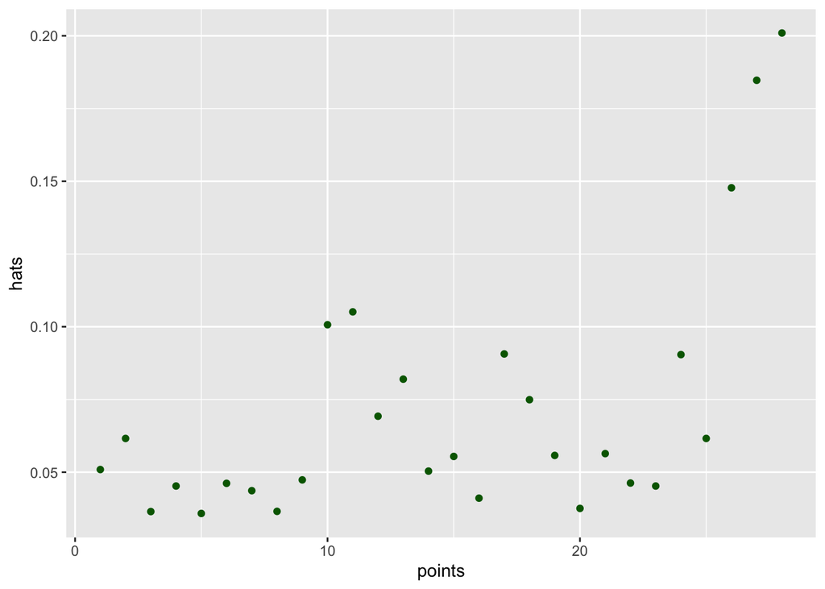

```r
#Check to see if any of the potential outliers create leverage
hats <- hatvalues(fit)

ggplot(data = NULL, aes(x = points, y = hats)) +
geom_point(colour = "darkgreen")
```

There do not appear to be any leverage points as **all hatvalues are closer to 0 than 1.**

### Further investigation of the points greater than 0.125 to ensure no leverage.

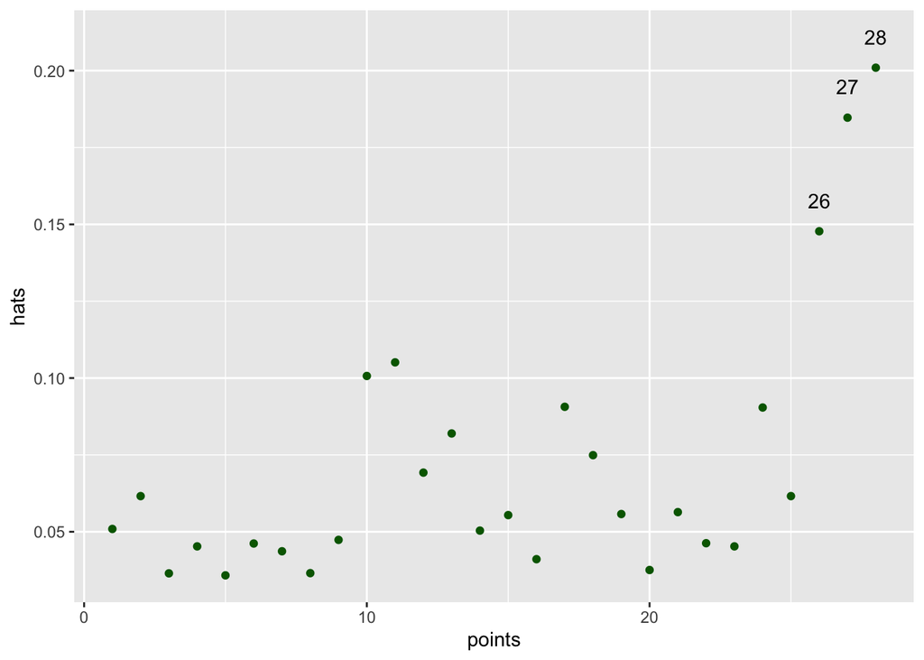

```r
hat_labels <- if_else(hats >= 0.125, paste(points), "")

ggplot(data = NULL, aes(x = points, y = hats)) +
geom_point(colour = "darkgreen") +
geom_text(aes(label = hat_labels), nudge_y = 0.01)
```

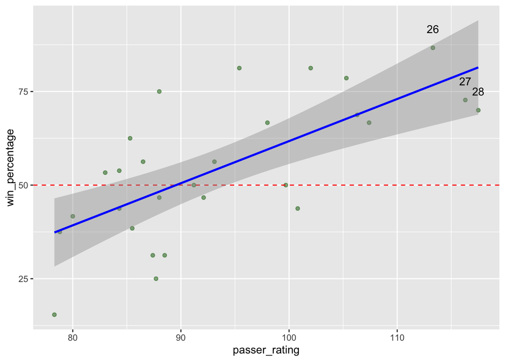

```r
ggplot(df2, aes(x = passer_rating, y = win_percentage))+
geom_point(alpha = 0.5, colour = "darkgreen")+
geom_hline(yintercept = 50, colour = "red", linetype = "dashed")+
geom_smooth(method = "lm", colour = "blue")+
theme_gray()+
geom_text(aes(label = hat_labels), nudge_y = 5)
```

These three points (26, 27 & 28) **do not seem to show overly high levels of leverage or influence.**

## Influential Points

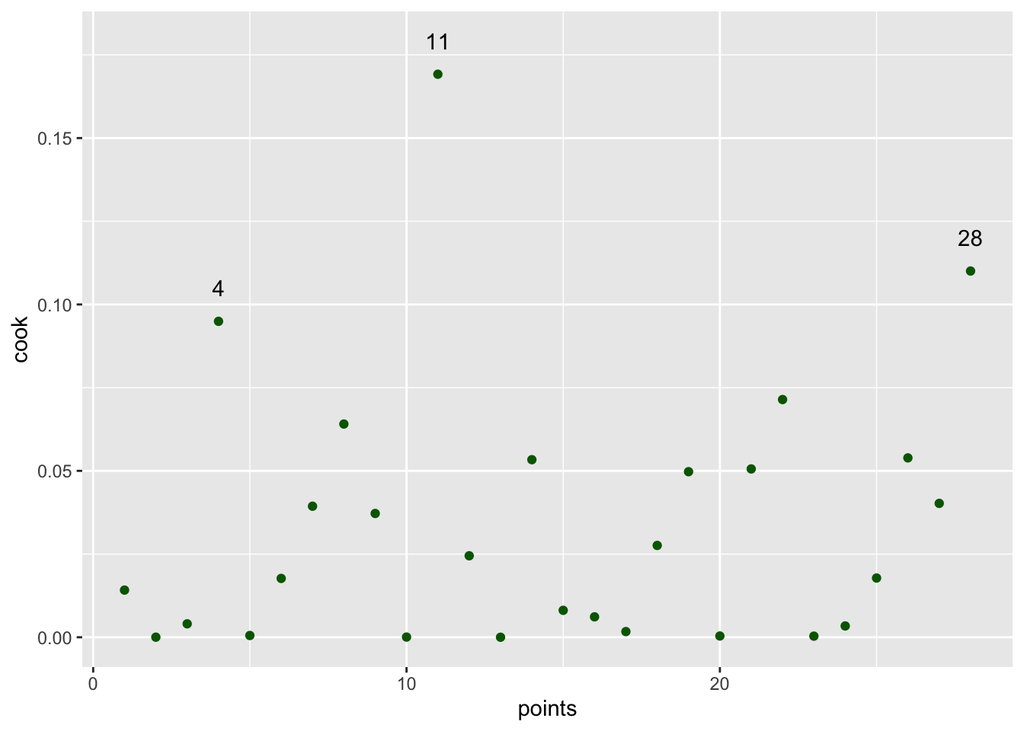

```r
#Check for influence on the linear regression by potential outliers
cook <-cooks.distance(fit)
cook_labels <- if_else(cook >= 0.075, paste(points), "")

ggplot(data = NULL, aes(x =points, y = cook)) +
geom_point(colour = "darkgreen")+
geom_text(aes(label = cook_labels), nudge_y =0.01)
```

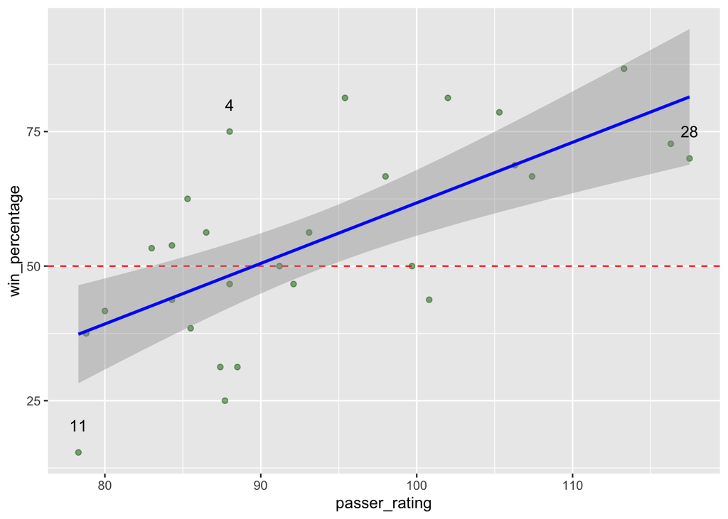

```r
ggplot(df2, aes(x = passer_rating, y = win_percentage))+
geom_point(alpha = 0.5, colour = "darkgreen")+
geom_hline(yintercept = 50, colour = "red", linetype = "dashed")+
geom_smooth(method = "lm", colour = "blue")+
theme_gray()+
geom_text(aes(label = cook_labels), nudge_y = 5)
```

It would appear that are two points (4 & 11) that are potentially influencing the data, and possibly point 28.

Point 4 appears to be a low leverage & low influence point.

Point 28 may have a moderate leverage and moderate influence.

We should re-run our analysis removing points 11 & 28. Object 28 is however case_no 29.

## Re-run Linear Regression

```r
#Removal of high influence points
outliers <- c(11, 29) #Object 28 is however case_no 29.
filtered_df2 <- df2 %>%
  filter(!case_no %in% outliers)
```

```r
fit2 <- lm(win_percentage ~ passer_rating, data = filtered_df2)

summary(fit2)
```

```
##
## Call:
## lm(formula = win_percentage ~ passer_rating, data = filtered_df2)
##
## Residuals:
##     Min      1Q  Median      3Q     Max
## -24.322  -7.995  -1.459   8.890  25.347
##
## Coefficients:
##               Estimate Std. Error t value Pr(>|t|)
## (Intercept)   -47.4588    24.3045  -1.953 0.062616 .
## passer_rating   1.1035     0.2588   4.265 0.000269 ***
## ---
## Signif. codes:  0 '***' 0.001 '**' 0.01 '*' 0.05 '.' 0.1 ' ' 1
##
## Residual standard error: 13.24 on 24 degrees of freedom
## Multiple R-squared:  0.4311, Adjusted R-squared:  0.4074
## F-statistic: 18.19 on 1 and 24 DF,  p-value: 0.0002693
```

```r
tidy(fit2, conf.int = TRUE)
```

```
## # A tibble: 2 x 7
##   term          estimate std.error statistic  p.value conf.low conf.high
##   <chr>            <dbl>     <dbl>     <dbl>    <dbl>    <dbl>     <dbl>
## 1 (Intercept)     -47.5     24.3       -1.95 0.0626    -97.6        2.70
## 2 passer_rating     1.10     0.259      4.26 0.000269    0.570      1.64
```

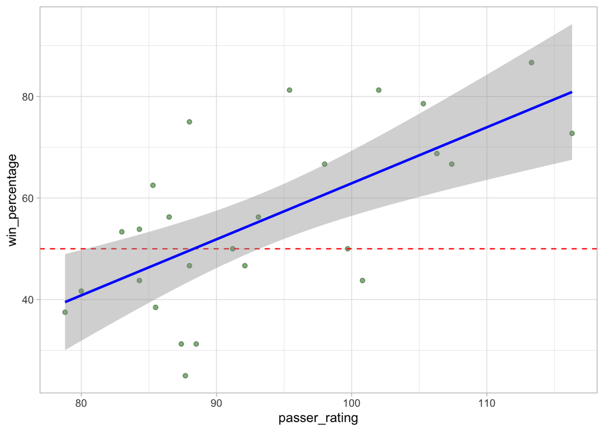

```r
#High influence points removed and re-run our intital model
ggplot(filtered_df2, aes(x = passer_rating, y = win_percentage))+
geom_point(alpha = 0.5, colour = "darkgreen")+
geom_hline(yintercept = 50, colour = "red", linetype = "dashed")+
geom_smooth(method = "lm", colour = "blue")+
theme_light()
```

There appears to minimal change to: slope intercept R-squared value

so it appears that there is no need to remove this potential High Influence data points.

## Homoscedasticity

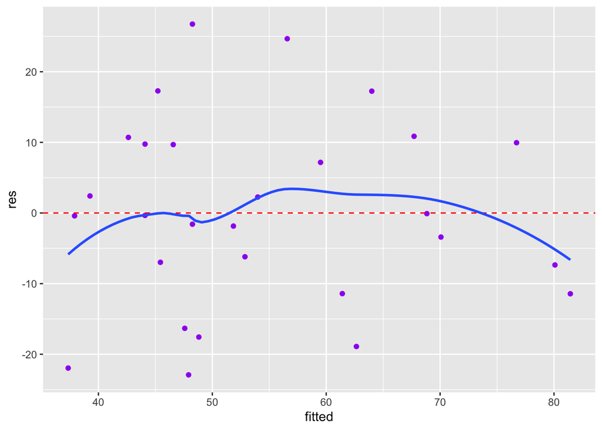

```r
#Plotting of the residuals against the fitted values
res <- residuals(fit)
fitted <- predict(fit)

ggplot(df2, aes(x = fitted, y = res))+
geom_point(colour = "purple")+
geom_hline(yintercept = 0, colour = "red", linetype = "dashed")+
geom_smooth(se = FALSE)
```

There appears to be no evidence of heteroscedasticity.

### Normality

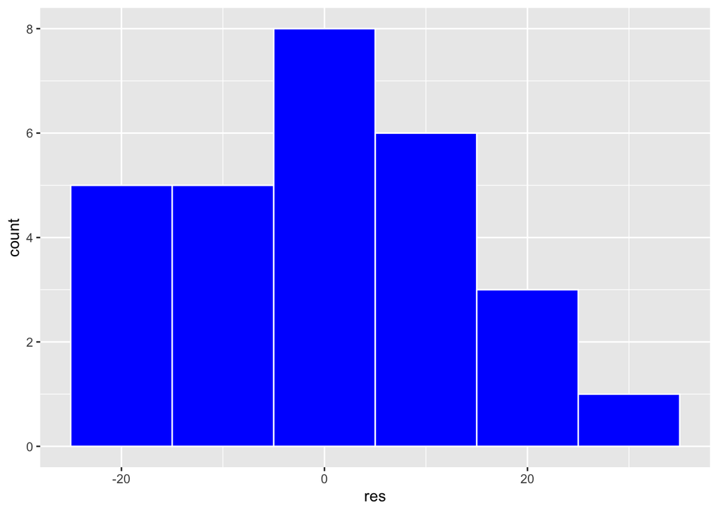

```r
#Is there a normal distribution

ggplot(data =NULL, aes(x= res))+
  geom_histogram( colour = "white", fill = "blue", binwidth = 10)
```

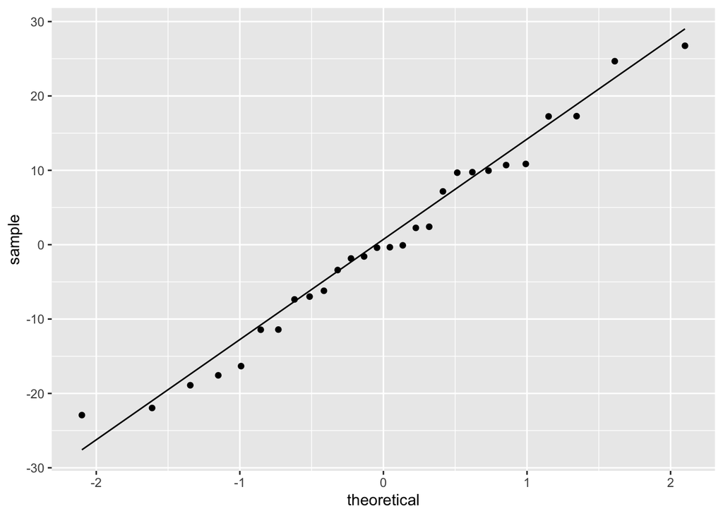

```r
ggplot(data = NULL, aes(sample =res))+
  stat_qq() + stat_qq_line()
```

The data points appear moderately normally distributed.

## Interpretation

**Considering the original questions, which were: Do quarterbacks with a higher passer rating have more wins? Do quarterbacks with a lower passer rating have fewer wins? How many wins can we expect to get when we have a starting quarterback with a particular passer rating?**

The data has a moderate correlation between Quarterback passer_rating and win_percentage. However, further exploratory analysis shows that passer_rating should not be the only metric used.

On average if a Quarterback can improve their passer_rating 1 point, they can improve their teams win_percentage 1.12%, so an improvement of 20 passer_rating points can make a significant difference (22%) to a teams prospect of winning games and being successful.

[^1]: University of Canberra. Applied Data Analysis in Sport PG (10157)